# Cooperativity of accessibility and binding

Melanie (1028-02098-001-001)

February 24, 2026

# Introduction

The goal of this analysis is to assess cooperativity at the level of directional, additive, and multiplicative relationships between both binding and accessibility. We will be testing this over an unopened and preopened state in silico. We will also be testing this pairwise cooperativity based on the genomic perturbations (based on motif pairs existing in the mapped hits).

# Computational Setup

```r
#Standard packages
library(rtracklayer) ; library(GenomicRanges); library(magrittr) ; library(Biostrings)
library(ggplot2) ; library(reshape2); library(plyranges); library(Rsamtools); library(parallel)
library(dplyr); library(data.table); library(patchwork); library(readr);

#KNITR Options
setwd("/n/projects/mw2098/publications/2024_weilert_acc/code/2_analysis/")
figure_filepath<-"figures/12_cooperativity"
options(knitr.figure_dir=figure_filepath, java.parameters = "- Xmx6g")

#Lab sources
source("scripts/r/granges_common.r")
source("scripts/r/metapeak_common.r")
source("scripts/r/knitr_common.r")
source("scripts/r/caching.r")
source("scripts/r/metapeak_functions.r")

#Specific sources
library(BSgenome.Mmusculus.UCSC.mm10)
library(ggseqlogo)
source("scripts/r/motif_functions.r")

dir.create(paste0(figure_filepath, '/insilico'), recursive = T, showWarnings = F)
dir.create(paste0(figure_filepath, '/genomic'), recursive = T, showWarnings = F)
dir.create(paste0(figure_filepath, '/pairs'), recursive = T, showWarnings = F)

#Pre-existing variables
threads <- 5
bsgenome<-BSgenome.Mmusculus.UCSC.mm10

bind_motif_to_task.list<-list('Oct4-Sox2' = 'oct4', 'Sox2' = 'sox2', 'Klf4' = 'klf4', 'Zic3' = 'zic3', 'Nanog' = 'nanog')
bind_motif_to_task.df<-data.frame(key_task = bind_motif_to_task.list %>% unlist, raw_motifA = names(bind_motif_to_task.list))

genomic_motifs.path<-'tsv/genomic/motifs/instances_formatted_for_genomic_perturbations_0based.tsv.gz'
motif_perturbs.path<-'tsv/mapped_motifs/all_instances_curated_0based_w_perturb.tsv.gz'
paired_perturbs.path<-'tsv/genomic/all_pairs_curated_0based_w_perturb.tsv.gz'

alternate_perturbs.path<-'tsv/genomic/all_pairs_curated_0based_w_alternate_perturb.tsv.gz'

region.path<-'tsv/mapped_motifs/all_islands_curated_1based_w_experimental_data.tsv.gz'
models_of_interest<-c('atac_wt', 'bpnet_osknz')
models.list<-list(bpnet_osknz = c('oct4','sox2','nanog','klf4','zic3'),
                  atac_wt = c('atac'),
                  atac_0h = c('atac'),
                  atac_3h = c('atac'),
                  atac_6h = c('atac'),
                  atac_9h = c('atac'),
                  atac_12h = c('atac'),
                  atac_15h = c('atac'))
region_ids_of_interest<-c(97547, 3491)

distance_class_breaks<-c(0, 70, 180, 1000)
distance_class_labels<-c('protein-range', 'nucleosome-range', 'enhancer-range')
marginalized_affinities.df<-readr::read_tsv('tsv/insilico/marginalizations/motifs/all_showcase.tsv.gz')

count_threshold<-20 #minimum frequency of grouped regions to compute median values

input_length<-2032
output_length<-1000
flank<-(input_length - output_length)/2
```

As mentioned in `10_*`, we did not consider Oct4 only motif in cooperative motif pairs because of its ERV-heavy enrichment and lack of enough instances to impute a generalized syntax of accessibility or binding.

# Depict theoretical saturation cooperativity effect

“Second, we can exclude a model where each pioneer TF independently removes the same nucleosome with a certain probability, causing increased accessibility across the cell population. If this were the case, this would produce less than additive effects.”

Generate theoretical plot.

```r
set.seed(2356)
saturation_premise.plot<-data.frame(o1 = sample(seq(0.01, 1, 0.01), size = 10000, replace = T),
           o2 = sample(seq(0.01, 1, 0.01), size = 10000, replace = T)) %>%
  dplyr::filter(o1 + o2 < 1) %>%
  dplyr::mutate(p_open = 1- ((1-o1)*(1-o2)),
                o_diff = abs(o1-o2)) %>%
  ggplot(., aes(x  = o1 + o2, y = p_open, color = o_diff))+
  geom_abline(slope = 1, intercept = 0, linetype = 'dashed')+
  ggrastr::geom_point_rast(size = .1)+
  scale_x_continuous(name = 'o1 + o2', limits = c(0, 1))+
  scale_y_continuous(name = 'popen', limits = c(0, 1))+
  scale_color_gradientn(name = 'abs(o1-o2)', colors = magma(10))+
  theme_classic()
ggsave(paste0(figure_filepath, '/saturation_formula_graphic.png'), saturation_premise.plot, height = 4, width = 4)
ggsave(paste0(figure_filepath, '/saturation_formula_graphic.pdf'), saturation_premise.plot, height = 4, width = 4)
```

# Assess perturb (context) cooperativity

Given predicted mutations of in vivo motifs, do we observe cooperativity?

## Import cooperativity predictions

Import all general regions

```r
regions.df<-readr::read_tsv(region.path)
```

Read in paired perturbations and process.

```r
all_perturbs.df<-readr::read_tsv(paired_perturbs.path) %>%
  dplyr::mutate(motif_pair_distance = abs(pattern_center.y - pattern_center.x)) %>%
  dplyr::rowwise() %>%
  dplyr::mutate(motif_pair_ordered = paste(sort(c(motif.x, motif.y)), collapse = " vs "),
                motif_pair_blind = paste0(motif.x, ' vs ', motif.y)) %>%
  #Remove directionality from pairs by removing one of A->B and B->A pairs
  # dplyr::filter(motif_pair_ordered==motif_pair_blind) %>%
  dplyr::ungroup()

# assert('Redundancies in motif pairs are still present', length(unique(all_perturbs.df %>% dplyr::filter(motif_pair_ordered == 'Klf4 vs Sox2') %>% .$motif.x %>% table))==1)
```

Collect perturbations and metadata of interest.

```r
perturbs.df<-mclapply(models_of_interest, function(x){
  p.df<-lapply(models.list[[x]], function(task){
    all_perturbs.df %>%
      dplyr::select(region_id, pair_name, pair_id, motif_pair_ordered, motif_pair_blind, motif_pair_distance, seq.x, seq.y,
                    motif.x, motif.y, seq_match_quantile.x, seq_match_quantile.y,
                    hAB_sum = !!sym(paste0(x, '/', task, '/hAB/pred_sum')),
                    hB_sum = !!sym(paste0(x, '/', task, '/hB/pred_sum')),
                    hA_sum = !!sym(paste0(x, '/', task, '/hA/pred_sum')),
                    null_sum = !!sym(paste0(x, '/', task, '/null/pred_sum'))) %>%
      dplyr::mutate(model_name = x,
                    task = task,
                    distance_class = cut(motif_pair_distance,
                                         breaks = distance_class_breaks,
                                         labels = distance_class_labels,
                                         include.lowest = T),
                    add_coop = (hAB_sum - null_sum)/(hA_sum + hB_sum - 2*null_sum),
                    dir_coop = (hAB_sum - (hB_sum - null_sum))/(hA_sum),
                    mult_coop = log(hAB_sum/null_sum)/log((hA_sum*hB_sum)/(null_sum*null_sum)),
                    joint_effects = hAB_sum - null_sum,
                    marginal_effects = hA_sum + hB_sum - 2*null_sum,
                    A_effects = hA_sum - null_sum,
                    B_effects = hB_sum - null_sum)
  }) %>% rbindlist(.)
}, mc.cores = 6) %>% rbindlist(.)
```

Collect perturbations for Rosa for her to assess features alongside her kinetics models.

```r
perturbs_processed.df<-lapply(names(bind_motif_to_task.list), function(y){
  task<-bind_motif_to_task.list[[y]]
  x<-'bpnet_osknz'
  df<-all_perturbs.df %>%
    dplyr::filter(`motif.x`==y) %>%
    dplyr::mutate(hAB_bind_sum = !!sym(paste0(x, '/', task, '/hAB/pred_sum')),
                  hB_bind_sum = !!sym(paste0(x, '/', task, '/hB/pred_sum')),
                  hA_bind_sum = !!sym(paste0(x, '/', task, '/hA/pred_sum')),
                  null_bind_sum = !!sym(paste0(x, '/', task, '/null/pred_sum'))) %>%
    dplyr::mutate(distance_class = cut(motif_pair_distance,
                                       breaks = distance_class_breaks,
                                       labels = distance_class_labels,
                                       include.lowest = T),
                  add_bind_coop = (hAB_bind_sum - null_bind_sum)/(hA_bind_sum + hB_bind_sum - 2*null_bind_sum),
                  dir_bind_coop = (hAB_bind_sum - (hB_bind_sum - null_bind_sum))/(hA_bind_sum),
                  mult_bind_coop = log(hAB_bind_sum/null_bind_sum)/log((hA_bind_sum*hB_bind_sum)/(null_bind_sum*null_bind_sum)))
  return(df)
}) %>% rbindlist() %>%
  dplyr::mutate(hAB_acc_sum = !!sym(paste0('atac_wt/atac/hAB/pred_sum')),
                hB_acc_sum = !!sym(paste0('atac_wt/atac/hB/pred_sum')),
                hA_acc_sum = !!sym(paste0('atac_wt/atac/hA/pred_sum')),
                null_acc_sum = !!sym(paste0('atac_wt/atac/null/pred_sum'))) %>%
  dplyr::mutate(distance_class = cut(motif_pair_distance,
                                     breaks = distance_class_breaks,
                                     labels = distance_class_labels,
                                     include.lowest = T),
                add_acc_coop = (hAB_acc_sum - null_acc_sum)/(hA_acc_sum + hB_acc_sum - 2*null_acc_sum),
                dir_acc_coop = (hAB_acc_sum - (hB_acc_sum - null_acc_sum))/(hA_acc_sum),
                mult_acc_coop = log(hAB_acc_sum/null_acc_sum)/log((hA_acc_sum*hB_acc_sum)/(null_acc_sum*null_acc_sum)))

readr::write_tsv(perturbs_processed.df, 'tsv/mapped_motifs/all_pairs_curated_0based_with_cooperativity.tsv.gz')
```

```r
perturbs_processed.df<-readr::read_tsv('tsv/mapped_motifs/all_pairs_curated_0based_with_cooperativity.tsv.gz')
```

## Showcase uneven motif pair affinities

We want to see whether very high and very low motif pairs are not cooperating as well as two mid-affinities. We mean: the absolute effect is not high because a low affinity motif can’t contribute much and the high affinity motif won’t really care.

First, select the top, middle, and bottom context scores of pioneers (independent of motif identity). We are using context scores because they show that the context-considered in vivo features of whether a motif will be reactive and cooperative relative to other features.

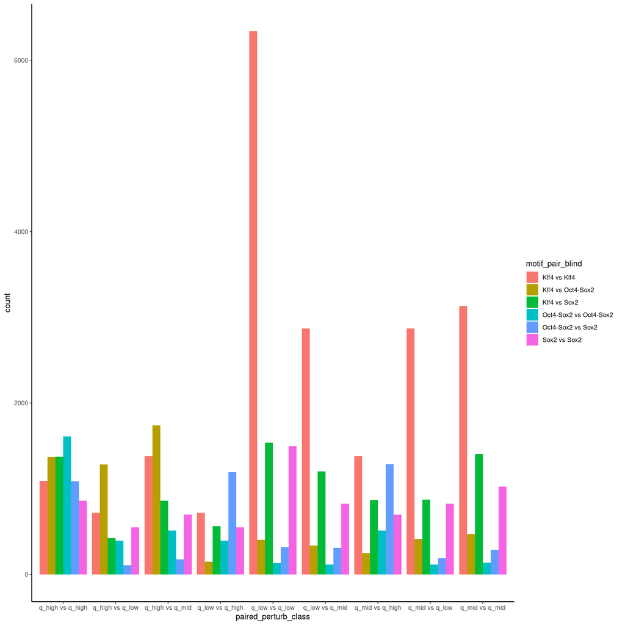

```r
upper_range<-.2
mid_range<-.2
lower_range<-.2
outlier<-0

perturb_candidates.df<-perturbs.df %>%
  dplyr::filter(model_name == 'atac_wt', task == 'atac', motif_pair_distance<=200, motif_pair_distance>=20) %>%
  dplyr::mutate(atac_wt_perturb_A = log(hAB_sum) - log(hA_sum),
                atac_wt_perturb_B = log(hAB_sum) - log(hB_sum)) %>%
  dplyr::filter(atac_wt_perturb_A>0, atac_wt_perturb_B>0,
                motif.x %in% c('Oct4-Sox2','Sox2', 'Klf4'),
                motif.y %in% c('Oct4-Sox2','Sox2', 'Klf4')) %>% #c('Sox2')) %>% #
  dplyr::mutate(atac_wt_perturb_A_q = ecdf(atac_wt_perturb_A)(atac_wt_perturb_A),
                atac_wt_perturb_B_q = ecdf(atac_wt_perturb_A)(atac_wt_perturb_B))%>%
  dplyr::filter(motif_pair_ordered==motif_pair_blind) %>% #remove redundant motifs
  dplyr::mutate(atac_wt_perturb_A_group = cut(atac_wt_perturb_A_q,
                                              breaks = c(-Inf, outlier, lower_range, .5-(mid_range/2),
                                                         .5+(mid_range/2), (1-upper_range), (1-outlier), Inf),
                                              labels = c('remove', 'q_low', 'remove', 'q_mid', 'remove', 'q_high', 'remove'),
                                              include.lowest = T),
                atac_wt_perturb_B_group = cut(atac_wt_perturb_B_q,
                                              breaks = c(-Inf, outlier, lower_range, .5-(mid_range/2),
                                                         .5+(mid_range/2), (1-upper_range), (1-outlier), Inf),
                                              labels = c('remove', 'q_low', 'remove', 'q_mid', 'remove', 'q_high', 'remove'),
                                              include.lowest = T)) %>%
  dplyr::filter(atac_wt_perturb_A_group!='remove', atac_wt_perturb_B_group!='remove') %>%
  dplyr::mutate(paired_perturb_class = paste0(`atac_wt_perturb_A_group`, ' vs ', `atac_wt_perturb_B_group`))

ggplot(perturb_candidates.df, aes(paired_perturb_class, fill = motif_pair_blind))+
  geom_bar(position = 'dodge')+
  theme_classic()
```

Plot the effects of different motif pairs based on their relative isolation scores.

```r
merged_class_index.df<-data.frame(paired_perturb_class = c("q_low vs q_low", "q_mid vs q_low", "q_mid vs q_mid", "q_low vs q_mid", "q_high vs q_mid", "q_high vs q_low", "q_mid vs q_high", "q_high vs q_high", "q_low vs q_high")) %>%
  dplyr::mutate(paired_perturb_class_merged = c("q_low vs q_low", "q_mid vs q_low", "q_mid vs q_mid", "q_mid vs q_low", "q_high vs q_mid", "q_high vs q_low", "q_high vs q_mid", "q_high vs q_high", "q_high vs q_low") %>%
                  factor(., levels = c("q_high vs q_low", "q_high vs q_mid", "q_high vs q_high", "q_mid vs q_mid", "q_mid vs q_low",  "q_low vs q_low")))

perturb_candidates_tidy.df<-perturb_candidates.df %>%
  dplyr::mutate(AB = hAB_sum - null_sum,
                A_unmerged = hA_sum - null_sum,
                B_unmerged = hB_sum - null_sum,
                null = null_sum) %>%

  #account for motifAmotifB or motifB motifA
  dplyr::left_join(merged_class_index.df) %>%
  tidyr::separate(paired_perturb_class_merged, into = c('left_class','right_class'), sep = ' vs ', remove = F) %>%
  dplyr::mutate(A = ifelse(paired_perturb_class_merged==paired_perturb_class, A_unmerged, B_unmerged),
                B = ifelse(paired_perturb_class_merged==paired_perturb_class, B_unmerged, A_unmerged),
                left_motif = ifelse(paired_perturb_class_merged==paired_perturb_class, `motif.x`, `motif.y`),
                right_motif = ifelse(paired_perturb_class_merged==paired_perturb_class, `motif.y`, `motif.x`)) %>%
  dplyr::select(-A_unmerged, -B_unmerged) %>%
  tidyr::pivot_longer(cols = c(AB, A, B, null), names_to = 'state', values_to = 'effects')

#group and summarize levels
perturb_candidates_summary.df<-perturb_candidates_tidy.df %>%
  dplyr::group_by(state, paired_perturb_class_merged) %>% #, motif_pair_blind) %>%
  dplyr::summarize(med_effects = median(effects)) %>%
  dplyr::mutate(state = factor(state, levels = c('AB', 'A','B', 'null')))

uneven_levels.plot<-ggplot(perturb_candidates_summary.df, aes(x = paired_perturb_class_merged))+
  geom_bar(aes(y = med_effects, fill = state), stat = 'identity', position = 'dodge')+
  geom_bar(data = perturb_candidates_summary.df %>% tidyr::pivot_wider(names_from = 'state', values_from = 'med_effects'),
           aes(y = A + B), stat = 'identity', position = 'dodge', fill = NA, width = .3, color = 'black')+
  ggtitle('pred levels')+
  # facet_grid(motif_pair_blind ~ .)+
  theme_classic()

# Measure which motifs went into each class.
left_uneven_motifs.plot<-perturb_candidates_tidy.df %>%
  dplyr::group_by(paired_perturb_class_merged, left_motif, right_motif) %>%
  dplyr::summarize(freq = dplyr::n()) %>%
  ggplot(., aes(x = paired_perturb_class_merged))+
  geom_bar(aes(y = freq, fill = left_motif), stat = 'identity', position = 'fill')+
  ggtitle('motifA identities')+
  theme_classic()

right_uneven_motifs.plot<-perturb_candidates_tidy.df %>%
  dplyr::group_by(paired_perturb_class_merged, left_motif, right_motif) %>%
  dplyr::summarize(freq = dplyr::n()) %>%
  ggplot(., aes(x = paired_perturb_class_merged))+
  geom_bar(aes(y = freq, fill = right_motif), stat = 'identity', position = 'fill')+
  ggtitle('motifB identities')+
  theme_classic()

print(perturb_candidates_tidy.df %>%
  dplyr::group_by(paired_perturb_class_merged, left_motif, right_motif) %>%
  dplyr::summarize(freq = dplyr::n()))
```

```
## # A tibble: 45 × 4
## # Groups:   paired_perturb_class_merged, left_motif [18]
##    paired_perturb_class_merged left_motif right_motif  freq
##    <fct>                       <chr>      <chr>       <int>
##  1 q_high vs q_low             Klf4       Klf4         5776
##  2 q_high vs q_low             Klf4       Oct4-Sox2    5136
##  3 q_high vs q_low             Klf4       Sox2         1708
##  4 q_high vs q_low             Oct4-Sox2  Klf4          588
##  5 q_high vs q_low             Oct4-Sox2  Oct4-Sox2    3168
##  6 q_high vs q_low             Oct4-Sox2  Sox2          424
##  7 q_high vs q_low             Sox2       Klf4         2248
##  8 q_high vs q_low             Sox2       Oct4-Sox2    4788
##  9 q_high vs q_low             Sox2       Sox2         4392
## 10 q_high vs q_mid             Klf4       Klf4        11048
## # ℹ 35 more rows
```

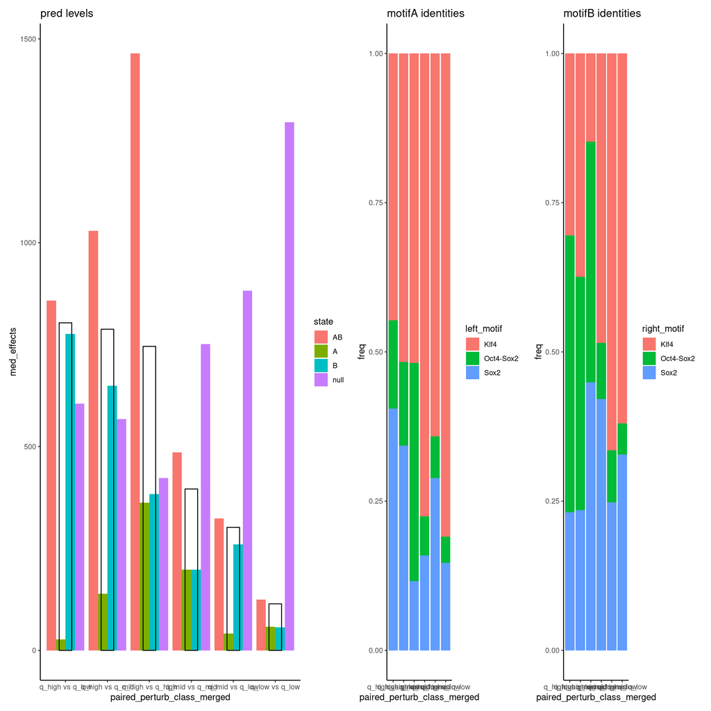

```r
uneven.metaplot<-uneven_levels.plot + left_uneven_motifs.plot + right_uneven_motifs.plot + plot_layout(nrow = 1, widths = c(4, 1, 1))
uneven.metaplot
```

```r
ggsave(paste0(figure_filepath, '/uneven_showcase.png'), uneven.metaplot, height = 4, width = 14)
ggsave(paste0(figure_filepath, '/uneven_showcase.pdf'), uneven.metaplot, height = 4, width = 14)
```

## Determine motif pair order

```r
motif_pair_blind_order<-perturbs.df %>%
  dplyr::group_by(motif_pair_blind) %>%
  dplyr::filter(motif_pair_distance <= 200, motif_pair_distance >=40, task == 'atac') %>%
  dplyr::summarize(y = median(add_coop)) %>%
  dplyr::arrange(y) %>% .$motif_pair_blind %>% unique

motif_pair_ordered_order<-perturbs.df %>%
  dplyr::group_by(motif_pair_ordered) %>%
  dplyr::filter(motif_pair_distance <= 200, motif_pair_distance >=40, task == 'atac') %>%
  dplyr::summarize(y = median(add_coop)) %>%
  dplyr::arrange(y) %>% .$motif_pair_ordered  %>% unique
```

## Assess joint vs marginal effects of each motif pair

### Genomic

```r
j_vs_m_all.plot<- perturbs.df %>%
  ggplot(., aes(marginal_effects, joint_effects, color = distance_class))+
  # geom_point(aes(color = color))+
  geom_abline(slope = 1, intercept = 0, linetype = 'dotted') +
  ggrastr::geom_point_rast(size = .2)+
  scale_x_continuous(name = 'Marginal effects (hA + hB - 2*h0)') +
  scale_y_continuous(name = 'Joint effects (hAB - h0)') +
  scale_color_manual(name = 'Distance', values = c('#b2182b', '#7F467F', '#4b73d2'))+
  facet_grid(model_name ~ .)+
  theme_classic() + theme(panel.background = element_rect(fill = 'white'))
ggsave(paste0(figure_filepath, '/genomic_perturbs_joint_vs_marg_colored_by_distance.png'), j_vs_m_all.plot,
       height = 4*length(models_of_interest), width = 6)
ggsave(paste0(figure_filepath, '/genomic_perturbs_joint_vs_marg_colored_by_distance.pdf'), j_vs_m_all.plot,
       height = 4*length(models_of_interest), width = 6)
```

Plot all pairs separately

```r
#Color by distance
filler<-lapply(all_perturbs.df$motif_pair_ordered %>% unique, function(x){
  message(x)
  j_vs_m_all.plot<- perturbs.df %>% dplyr::filter(motif_pair_ordered == x) %>%
    dplyr::arrange(rev(distance_class)) %>%
    ggplot(., aes(marginal_effects, joint_effects, color = distance_class))+
    # ggplot(., aes(marginal_effects, joint_effects))+
    # geom_point(aes(color = color))+
    geom_abline(slope = 1, intercept = 0, linetype = 'dotted') +
    ggrastr::geom_point_rast(size = .5)+
    scale_x_continuous(name = 'Marginal effects (hA + hB - 2*h0)', limits = c(-1000, 15000)) +
    scale_y_continuous(name = 'Joint effects (hAB - h0)', limits = c(-1000, 15000)) +
    scale_color_manual(name = 'Distance', values = viridis(n=3, begin = .2, end = 1))+
    ggtitle(x)+
    facet_grid(. ~ model_name)+
    theme_classic() + theme(panel.background = element_rect(fill = 'white'))

  # if(dim(perturbs.df %>% dplyr::filter(motif_pair_ordered==x, region_id %in% region_ids_of_interest))[1]>0){
  #   j_vs_m_all.plot<-j_vs_m_all.plot +
  #     geom_point(data = perturbs.df %>% dplyr::filter(motif_pair_ordered==x, region_id %in% region_ids_of_interest), color = 'black') +
  #     geom_text(data = perturbs.df %>% dplyr::filter(motif_pair_ordered==x, region_id %in% region_ids_of_interest), aes(label = region_id))
  # }

  plot<-j_vs_m_all.plot
  ggsave(paste0(figure_filepath, '/genomic/genomic_perturbs_joint_vs_marg_colored_by_distance_', x, '.png'), plot,
       height = 4, width = 5.5*length(models_of_interest)*1)
  ggsave(paste0(figure_filepath, '/genomic/genomic_perturbs_joint_vs_marg_colored_by_distance_', x, '.pdf'), plot,
       height = 4, width = 5.5*length(models_of_interest)*1)
  return(NULL)
})
```

## Devise significance test

So now we are in a tricky pickle. If we say cooperativity is when joint>marginal, then does this mean even 1% increase is cooperative? Standing on business, yes? But can we make a significance test to say “given a set of certain motif groups, are these more cooperative than the null expectation of no cooperativity?”. Now, “null expectation of no cooperativity” is hard because we don’t necessarily have replicates.

So we are going to declare to the world the following criteria:

### By motif pair

For individual motif pairs

```r
distance_feature<-400

perturbs_classed.df<-perturbs.df %>% dplyr::filter(task=='atac', motif_pair_distance >=30)  %>%
  dplyr::mutate(motif_pair_bin = ifelse(motif_pair_distance>=distance_feature, 'long', motif_pair_ordered)) %>%
  dplyr::mutate(motif_pair_bin = factor(motif_pair_bin, c('long', motif_pair_ordered_order))) %>%
  dplyr::arrange(motif_pair_bin) %>%
  dplyr::filter(!is.na(log(add_coop)))

paired.wilcox.test<-pairwise.wilcox.test(x = log(perturbs_classed.df$add_coop), g = perturbs_classed.df$motif_pair_bin, p.adjust.method = "bonf", alternative = 'greater')

padj.df<-data.frame(padj_to_long = paired.wilcox.test$p.value[,'long'])
padj.df$motif_pair_bin<-rownames(padj.df)

wilcox_across_pair.df<-padj.df %>% arrange(padj_to_long) %>%
  dplyr::mutate(sig = cut(padj_to_long, breaks = c(0, 1e-7, 1), labels = c('*', ''),
                          include.lowest = T, right = T)) %>%
  dplyr::select(-padj_to_long) %>%
  dplyr::mutate(motif_pair_bin = factor(motif_pair_bin, motif_pair_ordered_order)) %>%
  dplyr::arrange(desc(motif_pair_bin))
wilcox_across_pair.df
```

```
##                                motif_pair_bin sig
## Oct4-Sox2 vs Oct4-Sox2 Oct4-Sox2 vs Oct4-Sox2   *
## Oct4-Sox2 vs Sox2           Oct4-Sox2 vs Sox2   *
## Klf4 vs Oct4-Sox2           Klf4 vs Oct4-Sox2   *
## Klf4 vs Sox2                     Klf4 vs Sox2   *
## Sox2 vs Sox2                     Sox2 vs Sox2   *
## Klf4 vs Klf4                     Klf4 vs Klf4   *
## Sox2 vs Zic3                     Sox2 vs Zic3   *
## Oct4-Sox2 vs Zic3           Oct4-Sox2 vs Zic3   *
## Klf4 vs Zic3                     Klf4 vs Zic3   *
## Nanog vs Sox2                   Nanog vs Sox2   *
## Klf4 vs Nanog                   Klf4 vs Nanog   *
## Zic3 vs Zic3                     Zic3 vs Zic3   *
## Nanog vs Zic3                   Nanog vs Zic3   *
## Nanog vs Oct4-Sox2         Nanog vs Oct4-Sox2   *
## Nanog vs Nanog                 Nanog vs Nanog
```

### By distance bin

```r
distance_feature<-400

wilcox_paired_by_bin.df<-mclapply(perturbs.df$motif_pair_ordered %>% unique, function(x){

  p.df<-perturbs.df %>% dplyr::filter(motif_pair_ordered==x, task=='atac', motif_pair_distance >=30)  %>%
    dplyr::mutate(distance_bin = plyr::round_any(motif_pair_distance, 10, ceiling)) %>%
    dplyr::mutate(distance_bin_all = ifelse(distance_bin>=distance_feature, 'long', distance_bin)) %>%

    #Because we are using `pairwise.wilcox.test` it is really important that we order this data frame in this EXACT way
    #This allows us to apply the greater alternative hypothesis
    dplyr::arrange(desc(distance_bin)) %>%
    dplyr::mutate(distance_bin_all = factor(distance_bin_all, unique(distance_bin_all)))
  p.df$distance_bin_all %>% table

  paired.wilcox.test<-pairwise.wilcox.test(x = log(p.df$add_coop), g = p.df$distance_bin_all, p.adjust.method = "bonf", alternative = 'greater')
  padj.df<-data.frame(padj_to_long = paired.wilcox.test$p.value[,'long'])
  padj.df$distance_bin_all<-rownames(padj.df)
  padj.df$motif_pair_ordered<-x
  rownames(padj.df)<-NULL

  return(padj.df)

}, mc.cores = 8) %>% rbindlist() %>% arrange(padj_to_long) %>%
  dplyr::mutate(sig = cut(padj_to_long, breaks = c(0, 1e-7, 1), labels = c('*', ''),
  # dplyr::mutate(sig = cut(padj_to_long, breaks = c(0, 0.001, 0.01, 0.05, 1), labels = c('***','**', '*', ''),
                          include.lowest = T, right = T)) %>%
  dplyr::select(-padj_to_long) %>%
  dplyr::mutate(motif_pair_ordered = factor(motif_pair_ordered, motif_pair_ordered_order),
                distance_bin_all = as.integer(distance_bin_all)) %>%
  dplyr::arrange(distance_bin_all, desc(motif_pair_ordered)) %>%
  tidyr::pivot_wider(names_from = motif_pair_ordered, values_from = sig)

print(wilcox_paired_by_bin.df %>% as.data.frame())
```

```
##    distance_bin_all Oct4-Sox2 vs Oct4-Sox2 Oct4-Sox2 vs Sox2 Klf4 vs Oct4-Sox2
## 1                30                      *                 *                 *
## 2                40                      *                 *                 *
## 3                50                      *                 *                 *
## 4                60                      *                 *                 *
## 5                70                      *                 *                 *
## 6                80                      *                 *                 *
## 7                90                      *                 *                 *
## 8               100                      *                 *                 *
## 9               110                      *                 *                 *
## 10              120                      *                 *                 *
## 11              130                      *                 *
## 12              140                      *                 *                 *
## 13              150                      *                 *                 *
## 14              160                      *                 *                 *
## 15              170                      *                 *                 *
## 16              180                                        *                 *
## 17              190                                        *
## 18              200                                        *
## 19              210
## 20              220
## 21              230
## 22              240
## 23              250
## 24              260
## 25              270
## 26              280
## 27              290
## 28              300
## 29              310
## 30              320
## 31              330
## 32              340
## 33              350
## 34              360
## 35              370
## 36              380
## 37              390
##    Klf4 vs Sox2 Sox2 vs Sox2 Klf4 vs Klf4 Sox2 vs Zic3 Oct4-Sox2 vs Zic3
## 1             *            *                         *                 *
```

[output cut: 97 more lines]

```
## 23
## 24
## 25
## 26
## 27
## 28
## 29
## 30
## 31
## 32
## 33
## 34
## 35
## 36
## 37
```

```r
# View(wilcox_paired_by_bin.df %>% as.data.frame())
```

## Summarize cooperativity

### Summarize cooperativity (with distance)

How does cooperativity compare across all motif pairs?

```r
sig_marked.df<-wilcox_paired_by_bin.df %>% dplyr::rename(distance_bin = distance_bin_all) %>%
  tidyr::pivot_longer(cols = -distance_bin, names_to = 'motif_pair_ordered', values_to = 'sig')

summarize_all_distance.plot<-perturbs.df   %>%
  dplyr::mutate(distance_bin = plyr::round_any(motif_pair_distance, 10, ceiling)) %>%
  dplyr::group_by(task, motif_pair_ordered, distance_bin) %>%
  dplyr::summarize(median_add_coop = median(add_coop),
                   median_mult_coop = median(mult_coop),
                   median_dir_coop = median(dir_coop),
                   count = dplyr::n()/2) %>%
  dplyr::mutate(motif_pair_ordered = factor(motif_pair_ordered, levels = motif_pair_blind_order)) %>%
  tidyr::pivot_longer(cols = c(median_add_coop, median_mult_coop, median_dir_coop), names_to = 'coop_type', values_to = 'coop') %>%
  as.data.frame %>%
  dplyr::filter(count>=count_threshold) %>%
  ggplot(.)+
  # geom_tile()+
  ggrastr::geom_tile_rast(aes(x = distance_bin, y = motif_pair_ordered, fill = log(coop)))+
  geom_text(data = sig_marked.df, aes(x = distance_bin, y = motif_pair_ordered, label = sig), color = 'black')+
  scale_x_continuous(name = 'Distances', limits = c(0, 400)) +
  scale_y_discrete(name = 'Motif pair', expand = c(0,0)) +
  scale_fill_gradient2(high = '#b2182b', mid = 'white', low = '#2166ac', midpoint = 0, name = 'Coop. dist. (log)')+
  facet_grid(task ~ coop_type)+
  theme_classic()+  theme(panel.background = element_rect(fill = 'gray'))

ggsave(paste0(figure_filepath, '/genomic_coop_summary_all_motifs_with_distance.png'), summarize_all_distance.plot, height = 20, width = 24)
ggsave(paste0(figure_filepath, '/genomic_coop_summary_all_motifs_with_distance.pdf'), summarize_all_distance.plot, height = 20, width = 24)
```

Selected motif pairs with distance.

```r
summarize_selected_distance.plot<-perturbs.df %>%
  dplyr::group_by(task, motif_pair_ordered, motif_pair_distance) %>%
  dplyr::summarize(median_add_coop = median(add_coop),
                   median_mult_coop = median(mult_coop),
                   median_dir_coop = median(dir_coop),
                   count = dplyr::n()/2) %>%
  dplyr::mutate(motif_pair_ordered = factor(motif_pair_ordered, levels = motif_pair_blind_order)) %>%
  tidyr::pivot_longer(cols = c(median_add_coop, median_mult_coop, median_dir_coop), names_to = 'coop_type', values_to = 'coop') %>%
  as.data.frame %>%
  dplyr::filter(task == 'atac', coop_type == 'median_add_coop') %>%
  dplyr::filter(count>=count_threshold) %>%
  ggplot(., aes(x = motif_pair_distance, y = motif_pair_ordered, fill = log(coop)))+
  # geom_tile()+
  ggrastr::geom_tile_rast()+
  scale_x_continuous(name = 'Distances', limits = c(0, 400)) +
  scale_y_discrete(name = 'Motif pair', expand = c(0,0)) +
  scale_fill_gradient2(high = '#b2182b', mid = 'white', low = '#2166ac', midpoint = 0, name = 'Coop. dist. (log)')+
  facet_grid(task ~ coop_type)+
  theme_classic()+  theme(panel.background = element_rect(fill = 'gray'))

ggsave(paste0(figure_filepath, '/genomic_coop_summary_selected_motifs_with_distance.png'), summarize_selected_distance.plot, height = 6, width = 12)
ggsave(paste0(figure_filepath, '/genomic_coop_summary_selected_motifs_with_distance.pdf'), summarize_selected_distance.plot, height = 6, width = 12)
```

### Summarize perturb. cooperativity (no distance)

How does cooperativity compare across all motif pairs?

```r
summarize_all_pairs.plot<-perturbs.df %>%
  dplyr::group_by(task, motif_pair_ordered) %>%
  dplyr::summarize(median_add_coop = median(add_coop),
                   median_mult_coop = median(mult_coop),
                   median_dir_coop = median(dir_coop),
                   count = dplyr::n()/2) %>%
  dplyr::mutate(motif_pair_ordered = factor(motif_pair_ordered, levels = motif_pair_ordered_order)) %>%
  tidyr::pivot_longer(cols = c(median_add_coop, median_mult_coop, median_dir_coop), names_to = 'coop_type', values_to = 'coop') %>%
  as.data.frame %>%
  ggplot(., aes(x = task, y = motif_pair_ordered, fill = log(coop)))+
  # geom_tile()+
  geom_tile(color = 'black', size = .5)+
  scale_x_discrete(name = '', expand = c(0,0)) +
  scale_y_discrete(name = 'Motif pair', expand = c(0,0)) +
  scale_fill_gradient2(high = '#b2182b', mid = 'white', low = '#2166ac', midpoint = 0, name = ' coop (log)')+
  facet_grid(. ~ coop_type)+
  theme_classic()+  theme(panel.background = element_rect(fill = 'gray'))

ggsave(paste0(figure_filepath, '/genomic_coop_summary_all_motifs_no_distance.png'), summarize_all_pairs.plot, height = 6, width = 12)
ggsave(paste0(figure_filepath, '/genomic_coop_summary_all_motifs_no_distance.pdf'), summarize_all_pairs.plot, height = 6, width = 12)

summarize_selected_pairs.plot<-perturbs.df %>%
  dplyr::group_by(task, motif_pair_ordered) %>%
  dplyr::summarize(median_add_coop = median(add_coop),
                   median_mult_coop = median(mult_coop),
                   median_dir_coop = median(dir_coop),
                   count = dplyr::n()/2) %>%
  dplyr::mutate(motif_pair_ordered = factor(motif_pair_ordered, levels = motif_pair_ordered_order)) %>%
  tidyr::pivot_longer(cols = c(median_add_coop, median_mult_coop, median_dir_coop), names_to = 'coop_type', values_to = 'coop') %>%
  as.data.frame %>%
  dplyr::filter(task == 'atac', coop_type == 'median_add_coop') %>%
  ggplot(., aes(x = task, y = motif_pair_ordered, fill = log(coop)))+
  # geom_tile()+
  geom_tile(color = 'black', size = .5)+
  scale_x_discrete(name = '', expand = c(0,0)) +
  scale_y_discrete(name = 'Motif pair', expand = c(0,0)) +
  scale_fill_gradient2(high = '#b2182b', mid = 'white', low = '#2166ac', midpoint = 0, name = ' coop (log)', limits = c(-.05, .12))+
  facet_grid(. ~ coop_type)+
  theme_classic()+  theme(panel.background = element_rect(fill = 'gray'))

ggsave(paste0(figure_filepath, '/genomic_coop_summary_selected_motifs_no_distance.png'), summarize_selected_pairs.plot, height = 6, width = 4)
ggsave(paste0(figure_filepath, '/genomic_coop_summary_selected_motifs_no_distance.pdf'), summarize_selected_pairs.plot, height = 6, width = 4)
```

### Summarize cooperativity with low-affinity motif pairs (no distance)

```r
summarize_selected_pairs.plot<-perturbs_processed.df %>%
  dplyr::filter(seq_match_quantile.x <= .25) %>%
  dplyr::group_by(motif_pair_ordered) %>%
  dplyr::summarize(median_add_acc_coop = median(add_acc_coop),
                   count = dplyr::n()/2) %>%
  dplyr::mutate(motif_pair_ordered = factor(motif_pair_ordered, levels = motif_pair_blind_order)) %>%
  ggplot(., aes(x = 1, y = motif_pair_ordered, fill = log(median_add_acc_coop)))+
  # geom_tile()+
  geom_tile(color = 'black', size = .5)+
  scale_x_discrete(name = '', expand = c(0,0)) +
  scale_y_discrete(name = 'Motif pair', expand = c(0,0)) +
  scale_fill_gradient2(high = '#b2182b', mid = 'white', low = '#2166ac', midpoint = 0, name = ' coop (log)', limits = c(-.05, .12))+
  theme_classic()+  theme(panel.background = element_rect(fill = 'gray'))

ggsave(paste0(figure_filepath, '/genomic_coop_summary_lowaffinity_motifs_no_distance.png'), summarize_selected_pairs.plot, height = 6, width = 4)
ggsave(paste0(figure_filepath, '/genomic_coop_summary_lowaffinity_motifs_no_distance.pdf'), summarize_selected_pairs.plot, height = 6, width = 4)
```

### Median cooperativity by motif pair

Plot the median cooperativity by motif pair

```r
summarize_all.plot<-perturbs.df %>%
  dplyr::filter(task=='atac', motif_pair_distance <=300, motif_pair_distance >=30) %>%
  dplyr::group_by(motif_pair_ordered) %>%
  dplyr::summarize(median_add_coop = median(add_coop),
                   count = dplyr::n()/2) %>%
  dplyr::mutate(motif_pair_ordered = factor(motif_pair_ordered, levels = motif_pair_blind_order)) %>%
  as.data.frame %>%
  dplyr::filter(count>=count_threshold) %>%
  ggplot(., aes(x = motif_pair_ordered, y = log(median_add_coop), fill = log(median_add_coop)))+
  # geom_tile()+
  geom_bar(stat = 'identity', position = 'dodge', color = 'black')+
  scale_x_discrete(name = 'Motif pair') +
  scale_y_continuous(name = 'log(coop)') +
  coord_flip()+
  scale_fill_gradient2(high = '#b2182b', mid = 'white', low = '#2166ac', midpoint = 0, name = 'Coop (log)')+
  theme_classic()

ggsave(paste0(figure_filepath, '/genomic_coop_summary_all_motifs_medians.png'), summarize_all.plot, height = 10, width = 8)
ggsave(paste0(figure_filepath, '/genomic_coop_summary_all_motifs_medians.pdf'), summarize_all.plot, height = 10, width = 8)
```

#### Alternate models and cooperativity

Read in paired perturbations and process for all motifs for alternate models.

```r
alternate_perturbs.df<-readr::read_tsv(alternate_perturbs.path) %>%
    dplyr::mutate(motif_pair_distance = abs(pattern_center.y - pattern_center.x)) %>%
    dplyr::rowwise() %>%
    dplyr::mutate(motif_pair_ordered = paste(sort(c(motif.x, motif.y)), collapse = " vs "),
                  motif_pair_blind = paste0(motif.x, ' vs ', motif.y)) %>%
    #Remove directionality from pairs by removing one of A->B and B->A pairs
    # dplyr::filter(motif_pair_ordered==motif_pair_blind) %>%
    dplyr::ungroup()
```

Per model, process the paired perturbations.

```r
alternate_model_summary.df<-mclapply(c('atac_wt_across_genome', 'atac_wt_across_acc', 'atac_wt_across_split'), function(x){
  message(x)
  task<-'atac'
  p_summary.df<- alternate_perturbs.df %>%
    dplyr::select(region_id, pair_name, pair_id, motif_pair_ordered, motif_pair_blind, motif_pair_distance, seq.x, seq.y,
                  motif.x, motif.y, seq_match_quantile.x, seq_match_quantile.y,
                  hAB_sum = !!sym(paste0(x, '/', task, '/hAB/pred_sum')),
                  hB_sum = !!sym(paste0(x, '/', task, '/hB/pred_sum')),
                  hA_sum = !!sym(paste0(x, '/', task, '/hA/pred_sum')),
                  null_sum = !!sym(paste0(x, '/', task, '/null/pred_sum'))) %>%
    dplyr::filter(motif_pair_distance <=300, motif_pair_distance >=30) %>%
    dplyr::mutate(add_coop = (hAB_sum - null_sum)/(hA_sum + hB_sum - 2*null_sum),
                  log_coop = log(add_coop)) %>%
    dplyr::group_by(motif_pair_ordered) %>%
    dplyr::summarize(median_log_add_coop = median(log_coop, na.rm = T),
                     count = dplyr::n()/2) %>%
    dplyr::mutate(motif_pair_ordered = factor(motif_pair_ordered, levels = motif_pair_blind_order)) %>%
    as.data.frame %>%
    dplyr::filter(count>=count_threshold) %>%
    dplyr::select(-count) %>%
    dplyr::mutate(model = x)
  return(p_summary.df)

}) %>% rbindlist() %>% tidyr::pivot_wider(names_from = model, values_from  = median_log_add_coop)

#Join WT values
original_summary.df<-perturbs.df %>%
  dplyr::mutate(log_add_coop = log(add_coop)) %>%
  dplyr::filter(task=='atac', motif_pair_distance <=300, motif_pair_distance >=30) %>%
  dplyr::group_by(motif_pair_ordered) %>%
  dplyr::summarize(atac_wt_original = median(log_add_coop, na.rm = T))

all_summary.df<-alternate_model_summary.df %>%
  dplyr::left_join(original_summary.df %>% dplyr::select(motif_pair_ordered, atac_wt_original))
readr::write_tsv(all_summary.df, 'tsv/motif_cooperativities_across_models.tsv')
```

### Summarize cooperativity with low-affinity motif pairs (with distance)

```r
summarize_selected_distance.plot<-perturbs_processed.df %>%
  dplyr::filter(seq_match_quantile.x <= .25) %>%
  dplyr::group_by(motif_pair_ordered, motif_pair_distance) %>%
  dplyr::summarize(median_add_acc_coop = median(add_acc_coop),
                   count = dplyr::n()/2) %>%
  dplyr::mutate(motif_pair_ordered = factor(motif_pair_ordered, levels = motif_pair_blind_order)) %>%
  dplyr::filter(count>=count_threshold) %>%
  ggplot(., aes(x = motif_pair_distance, y = motif_pair_ordered, fill = log(median_add_acc_coop)))+
  # geom_tile()+
  ggrastr::geom_tile_rast()+
  scale_x_continuous(name = 'Distances', limits = c(0, 400)) +
  scale_y_discrete(name = 'Motif pair', expand = c(0,0)) +
  scale_fill_gradient2(high = '#b2182b', mid = 'white', low = '#2166ac', midpoint = 0, name = 'Coop. dist. (log)', limits = c(-.25, .6))+
  theme_classic()+  theme(panel.background = element_rect(fill = 'gray'))

ggsave(paste0(figure_filepath, '/genomic_coop_summary_lowaff_motifs_with_distance.png'), summarize_selected_distance.plot, height = 6, width = 12)
ggsave(paste0(figure_filepath, '/genomic_coop_summary_lowaff_motifs_with_distance.pdf'), summarize_selected_distance.plot, height = 6, width = 12)
```

## Assess impact of affinity over distance on cooperativity

First, create summary groups and information by which to consolidate data.

```r
perturbs.df<-perturbs.df %>% as.data.frame %>%
  dplyr::filter(!is.na(distance_class)) %>%
  dplyr::mutate(distance_bin_narrow = plyr::round_any(motif_pair_distance, 5, ceiling),
                distance_bin_medium = plyr::round_any(motif_pair_distance, 10, ceiling),
                distance_bin_wide = plyr::round_any(motif_pair_distance, 20, ceiling),
                ic_match_q_A = ifelse(`motif.x`==stringr::str_split(string = motif_pair_ordered, pattern = ' vs ', n = 1),
                                      `seq_match_quantile.x`, `seq_match_quantile.y`),
                ic_match_q_B = ifelse(`motif.x`==stringr::str_split(string = motif_pair_ordered, pattern = ' vs ', n = 1),
                                      `seq_match_quantile.y`, `seq_match_quantile.x`),
                motifA_ic_match_q_bin = plyr::round_any(ic_match_q_A, .25, ceiling),
                motifB_ic_match_q_bin = plyr::round_any(ic_match_q_B, .25, ceiling),
                affinity_bin = paste0(motifA_ic_match_q_bin, ' vs ', motifB_ic_match_q_bin))
```

Next assess impact of different metrics for each motif pair.

```r
genomic_affinity_summary.df<-perturbs.df %>%
  dplyr::left_join(., regions.df %>% dplyr::select(region_id, atac_obs, atac_pred, island_count)) %>%
  dplyr::mutate(motifA_ic_match_q_bin_narrow = plyr::round_any(ic_match_q_A, .25, ceiling),
                motifB_ic_match_q_bin_narrow = plyr::round_any(ic_match_q_B, .25, ceiling),
                affinity_bin = paste0(motifA_ic_match_q_bin_narrow, ' vs ', motifB_ic_match_q_bin_narrow),
                effect_size =  (hA_sum - null_sum) + (hB_sum - null_sum),
                effect_size_A = (hA_sum - null_sum),
                effect_size_B = (hB_sum - null_sum),
                cooperative_effect_size = hAB_sum - (hA_sum + hB_sum - null_sum*2) - null_sum) %>%
  dplyr::group_by(motif_pair_ordered, affinity_bin, motifB_ic_match_q_bin_narrow, motifA_ic_match_q_bin_narrow, distance_bin_medium, model_name) %>%
  dplyr::summarize(median_add_coop = median(add_coop),
                   median_obs = median(atac_obs),
                   median_pred = median(atac_pred),
                   median_effect_size = median(effect_size),
                   median_effect_size_A = median(effect_size_A),
                   median_effect_size_B = median(effect_size_B),
                   median_cooperative_effect_size = median(cooperative_effect_size),
                   count = dplyr::n(),
                   median_island_count = median(island_count)) %>%
  dplyr::filter(count>=count_threshold)

filler<-lapply(all_perturbs.df$motif_pair_ordered %>% unique, function(x){
  affinity_vs_coop.plot<-genomic_affinity_summary.df %>%
    dplyr::filter(motif_pair_ordered==x) %>%
    ggplot(., aes(x = distance_bin_medium,  y = affinity_bin, fill = log(median_add_coop)))+
    geom_tile()+
    scale_x_continuous(name = 'Distances', limits = c(0, 300)) +
    scale_y_discrete(name = 'Motif pair', expand = c(0,0)) +
    scale_fill_gradient2(high = '#b2182b', mid = 'white', low = '#2166ac', midpoint = 0, name = 'Coop. (log)')+
    ggtitle(x)+
    facet_grid(. ~ model_name)+
    theme_classic()+  theme(panel.background = element_rect(fill = 'gray'), legend.position = 'bottom')

  affinity_vs_obs.plot<-genomic_affinity_summary.df %>%
    dplyr::filter(motif_pair_ordered==x) %>%
    ggplot(., aes(x = distance_bin_medium,  y = affinity_bin, fill = median_obs))+
    geom_tile()+
    scale_x_continuous(name = 'Distances', limits = c(0, 300)) +
    scale_y_discrete(name = 'Motif pair', expand = c(0,0)) +
    scale_fill_gradient(high = '#7c576c', low = 'white', name = 'Obs ATAC')+
    ggtitle(x)+
    facet_grid(. ~ model_name)+
    theme_classic()+  theme(panel.background = element_rect(fill = 'gray'), legend.position = 'bottom')

  affinity_vs_pred.plot<-genomic_affinity_summary.df %>%
    dplyr::filter(motif_pair_ordered==x) %>%
    ggplot(., aes(x = distance_bin_medium,  y = affinity_bin, fill = median_pred))+
    geom_tile()+
    scale_x_continuous(name = 'Distances', limits = c(0, 300)) +
    scale_y_discrete(name = 'Motif pair', expand = c(0,0)) +
    scale_fill_gradient(high = '#30506e', low = 'white', name = 'pred ATAC')+
    ggtitle(x)+
    facet_grid(. ~ model_name)+
    theme_classic()+  theme(panel.background = element_rect(fill = 'gray'), legend.position = 'bottom')

  affinity_vs_effect_size.plot<-genomic_affinity_summary.df %>%
    dplyr::filter(motif_pair_ordered==x) %>%
    ggplot(., aes(x = distance_bin_medium,  y = affinity_bin, fill = median_effect_size))+
    geom_tile()+
    scale_x_continuous(name = 'Distances', limits = c(0, 300)) +
    scale_y_discrete(name = 'Motif pair', expand = c(0,0)) +
    scale_fill_gradient(high = '#016c59', low = 'white', name = 'effect_size ATAC')+
    ggtitle(x)+
    facet_grid(. ~ model_name)+
    theme_classic()+  theme(panel.background = element_rect(fill = 'gray'), legend.position = 'bottom')

  # affinity_vs_effect_size_A.plot<-genomic_affinity_summary.df %>%
  #   dplyr::filter(motif_pair_ordered==x) %>%
  #   ggplot(., aes(x = distance_bin_medium,  y = affinity_bin, fill = median_effect_size_A))+
  #   geom_tile()+
  #   scale_x_continuous(name = 'Distances', limits = c(0, 300)) +
  #   scale_y_discrete(name = 'Motif pair', expand = c(0,0)) +
  #   scale_fill_gradient(high = '#016c59', low = 'white', name = 'effect_size ATAC A')+
  #   ggtitle(x)+
  #   facet_grid(. ~ model_name)+
  #   theme_classic()+  theme(panel.background = element_rect(fill = 'gray'), legend.position = 'bottom')
  #
  # affinity_vs_effect_size_B.plot<-genomic_affinity_summary.df %>%
  #   dplyr::filter(motif_pair_ordered==x) %>%
  #   ggplot(., aes(x = distance_bin_medium,  y = affinity_bin, fill = median_effect_size_B))+
  #   geom_tile()+
  #   scale_x_continuous(name = 'Distances', limits = c(0, 300)) +
  #   scale_y_discrete(name = 'Motif pair', expand = c(0,0)) +
  #   scale_fill_gradient(high = '#016c59', low = 'white', name = 'effect_size ATAC B')+
  #   ggtitle(x)+
  #   facet_grid(. ~ model_name)+
  #   theme_classic()+  theme(panel.background = element_rect(fill = 'gray'), legend.position = 'bottom')

  affinity_vs_coop_effect_size.plot<-genomic_affinity_summary.df %>%
    dplyr::filter(motif_pair_ordered==x) %>%
    ggplot(., aes(x = distance_bin_medium,  y = affinity_bin, fill = median_cooperative_effect_size))+
    geom_tile()+
    scale_x_continuous(name = 'Distances', limits = c(0, 300)) +
    scale_y_discrete(name = 'Motif pair', expand = c(0,0)) +
    scale_fill_gradient(high = '#9e8931', low = 'white', name = 'coop_effect_size ATAC')+
    ggtitle(x)+
    facet_grid(. ~ model_name)+
    theme_classic()+  theme(panel.background = element_rect(fill = 'gray'), legend.position = 'bottom')

  metaplot<-affinity_vs_obs.plot + affinity_vs_pred.plot + affinity_vs_effect_size.plot + affinity_vs_coop_effect_size.plot + affinity_vs_coop.plot +
    plot_layout(nrow = 1)

  ggsave(paste0(figure_filepath, '/genomic/genomic_perturbs_metaplots_vs_selected_affinity_and_distance_heatmaps_', x, '.png'), metaplot, height = 6, width = 24)
  ggsave(paste0(figure_filepath, '/genomic/genomic_perturbs_metaplots_vs_selected_affinity_and_distance_heatmaps_', x, '.pdf'), metaplot, height = 6, width = 24)
})
```

## Assess effect sizes at all motifs

Collect activity and nearest gene distance across regions.

```r
regions.gr<-GenomicRanges::resize(makeGRangesFromDataFrame(regions.df), 2000, 'center')
```

Cooperativity summaries.

```r
affinity_groups_of_interest<-c('0.25 vs 0.25', '0.5 vs 0.5', '1 vs 1')
genomic_by_affinity.df<-perturbs.df %>%
  dplyr::left_join(., regions.df %>% dplyr::select(region_id, atac_obs, atac_pred, island_count, nearest_gene_distance, CpG_ratio)) %>%
  dplyr::mutate(motifA_ic_match_q_bin_narrow = plyr::round_any(ic_match_q_A, .25, ceiling),
                motifB_ic_match_q_bin_narrow = plyr::round_any(ic_match_q_B, .25, ceiling),
                affinity_bin = paste0(motifA_ic_match_q_bin, ' vs ', motifB_ic_match_q_bin)) %>%
  dplyr::filter(distance_class != 'long-range') %>%
  dplyr::group_by(motif_pair_ordered, affinity_bin, distance_class) %>%
  dplyr::summarize(median_add_coop = median(add_coop),
                   median_obs = median(atac_obs),
                   median_pred = median(atac_pred),
                   count = dplyr::n(),
                   median_nearest_gene_distance = median(nearest_gene_distance),
                   median_island_count = median(island_count),
                   median_CpG_ratio = median(CpG_ratio)) %>%
  dplyr::filter(count>=count_threshold, affinity_bin %in% affinity_groups_of_interest)  %>%
  dplyr::mutate(affinity_bin = factor(affinity_bin, levels = affinity_groups_of_interest, labels = c('low', 'medium','high')),
                motif_pair_ordered = factor(motif_pair_ordered, motif_pair_ordered_order))

affinity_vs_coop.plot<-ggplot(genomic_by_affinity.df, aes(x = distance_class, y = motif_pair_ordered, fill = log(median_add_coop)))+
  # geom_tile()+
  geom_tile(color = 'black', size = .5)+
  scale_x_discrete(name = 'Distance class', expand = c(0,0)) +
  scale_y_discrete(name = 'Motif pair', expand = c(0,0)) +
  scale_fill_gradient2(high = '#b2182b', mid = 'white', low = '#2166ac', midpoint = 0, name = 'Add. coop (log)')+
  facet_wrap(~affinity_bin, nrow = 1)+
  theme_classic()+  theme(panel.background = element_rect(fill = 'gray'))

affinity_vs_obs.plot<-ggplot(genomic_by_affinity.df, aes(x = distance_class, y = motif_pair_ordered, fill = median_obs))+
  geom_tile(color = 'black', size = .5)+
  scale_x_discrete(name = 'Distance class', expand = c(0,0)) +
  scale_y_discrete(name = 'Motif pair', expand = c(0,0)) +
  scale_fill_gradient(high = '#7c576c', low = 'white', name = 'Obs ATAC')+
  ggtitle('Obs')+
  facet_wrap(~affinity_bin, nrow = 1)+
  theme_classic()+  theme(panel.background = element_rect(fill = 'gray'))

affinity_vs_pred.plot<-ggplot(genomic_by_affinity.df, aes(x = distance_class, y = motif_pair_ordered, fill = median_pred))+
  geom_tile(color = 'black', size = .5)+
  scale_x_discrete(name = 'Distance class', expand = c(0,0)) +
  scale_y_discrete(name = 'Motif pair', expand = c(0,0)) +
  scale_fill_gradient(high = '#30506e', low = 'white', name = 'pred ATAC')+
  ggtitle('Pred')+
  facet_wrap(~affinity_bin, nrow = 1)+
  theme_classic()+  theme(panel.background = element_rect(fill = 'gray'))

affinity_vs_CpG_ratio.plot<-ggplot(genomic_by_affinity.df, aes(x = distance_class, y = motif_pair_ordered, fill = median_CpG_ratio))+
  geom_tile(color = 'black', size = .5)+
  scale_x_discrete(name = 'Distance class', expand = c(0,0)) +
  scale_y_discrete(name = 'Motif pair', expand = c(0,0)) +
  scale_fill_gradient(high = 'navy', low = 'white', name = 'median_CpG_ratio')+
  ggtitle('median_CpG_ratio')+
  facet_wrap(~affinity_bin, nrow = 1)+
  theme_classic()+  theme(panel.background = element_rect(fill = 'gray'))

plot<-affinity_vs_coop.plot + affinity_vs_obs.plot + affinity_vs_pred.plot + affinity_vs_CpG_ratio.plot

ggsave(paste0(figure_filepath, '/genomic_perturbs_effects_vs_selected_affinity_and_distance_class_heatmaps.png'), plot, height = 8, width = 16)
ggsave(paste0(figure_filepath, '/genomic_perturbs_effects_vs_selected_affinity_and_distance_class_heatmaps.pdf'), plot, height = 8, width = 16)
```

## Assess saturation effects on cooperativity

If there are two extremely high affinity motifs, then will they show high cooperativity? Or will they saturate because the region is already sufficiently open?

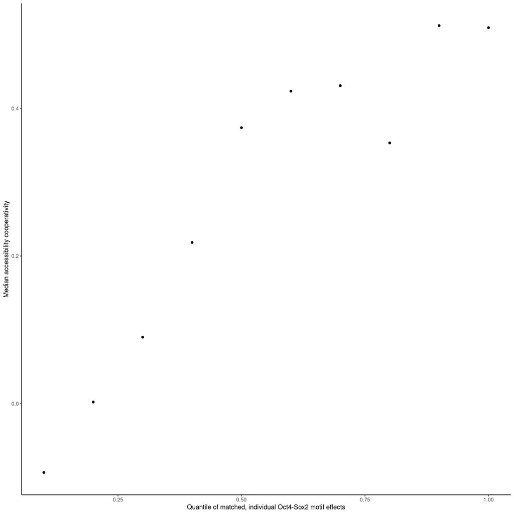

```r
ranked.df<-perturbs_processed.df %>%
  dplyr::filter(motif_pair_blind == 'Oct4-Sox2 vs Oct4-Sox2') %>%
  dplyr::mutate(A_effects = hAB_acc_sum - hA_acc_sum,
                B_effects = hAB_acc_sum - hB_acc_sum,
                AB_effects = A_effects + B_effects)

ranked_effects_dist<-ecdf(c(ranked.df$A_effects, ranked.df$B_effects))
ranked_sum_dist<-ecdf(c(ranked.df$A_effects + ranked.df$B_effects))

#Take motif pairs that contain exactly the same quantile range of response.
#This is done to filter "equally strong or equally weak motifs in terms of the response they evoke, not affinity or arrangement"

ranked_filtered.df<-ranked.df %>%
  dplyr::mutate(log_add_acc_coop = log(add_acc_coop),
                AB_q = ranked_sum_dist(AB_effects),
                AB_q_bin = plyr::round_any(AB_q, .01, ceiling),
                A_q = ranked_effects_dist(ranked.df$A_effects),
                B_q = ranked_effects_dist(ranked.df$B_effects),
                A_q_bin = plyr::round_any(A_q, .1, ceiling),
                B_q_bin = plyr::round_any(B_q, .1, ceiling),
                A_q_bin_smaller = plyr::round_any(A_q, .1, ceiling)) %>%
  dplyr::filter(A_q_bin==B_q_bin)

#Summarize by quantile effects to get stable plot
rank_summary.df<-ranked_filtered.df %>%
  dplyr::group_by(A_q_bin_smaller) %>%
  dplyr::summarize(med_log_add_acc_coop = median(log_add_acc_coop, na.rm = T),
                   med_distance = median(motif_pair_distance),
                   freq = dplyr::n())

saturation_effects.plot<-ggplot(rank_summary.df, aes(x = A_q_bin_smaller, y = med_log_add_acc_coop))+#, color = med_distance))+
  geom_point()+
  scale_x_continuous(name = 'Quantile of matched, individual Oct4-Sox2 motif effects')+
  scale_y_continuous(name = 'Median accessibility cooperativity')+
  # scale_color_gradientn(colors = viridis(10))+
  theme_classic()
saturation_effects.plot
```

```r
ggsave(paste0(figure_filepath, '/saturation_effect_matched_OS_medians.png'), saturation_effects.plot, height = 4, width = 6)
ggsave(paste0(figure_filepath, '/saturation_effect_matched_OS_medians.pdf'), saturation_effects.plot, height = 4, width = 6)
```

## Examine relationship between affinity and cooperativity

In our thermodynamics modeling, we observe that affinity and cooperativity are correlated (even relatively). In our data, we also observe this, albeit weakly. How do these two things compare?

```r
coop_vs_aff.plot<-perturbs.df %>%
  dplyr::filter(!grepl('Zic3|Nanog', motif_pair_ordered)) %>%
  dplyr::filter(motifA_ic_match_q_bin==motifB_ic_match_q_bin) %>%
  dplyr::mutate(motifA_ic_match_q_bin = factor(motifA_ic_match_q_bin, levels = c(0.25, 0.5, 0.75, 1))) %>%
  ggplot(., aes(x = log(add_coop), color = motifA_ic_match_q_bin, group = motifA_ic_match_q_bin))+
  geom_density()+
  facet_grid(motif.x~motif.y)+
  scale_x_continuous(limits = c(-2, 2))+
  theme_classic()
ggsave(paste0(figure_filepath, '/coop_vs_affinity_density.png'), coop_vs_aff.plot, height = 8, width = 16)
ggsave(paste0(figure_filepath, '/coop_vs_affinity_density.pdf'), coop_vs_aff.plot, height = 8, width = 16)
```

## Statistics on low-affinity motif effects

### ANOVA test on (coop ~ distance + affinityA * affinityB)

Are low-affinity motifs less cooperative than high-affinity motifs? Statistically model this.

```r
filler<-lapply(all_perturbs.df$motif_pair_ordered %>% unique, function(x){

  p.df<-perturbs.df %>% dplyr::filter(motif_pair_ordered==x, model_name=='atac_wt')
  aov.test<-summary(aov(add_coop ~ motifA_ic_match_q_bin*motifB_ic_match_q_bin+motif_pair_distance, data = p.df))
  print(x)
  print(aov.test)
})
```

```
## [1] "Klf4 vs Klf4"
##                                                 Df    Sum Sq Mean Sq F value
## motifA_ic_match_q_bin                            1     14295   14295   1.903
## motifB_ic_match_q_bin                            1     10126   10126   1.348
## motif_pair_distance                              1      7888    7888   1.050
## motifA_ic_match_q_bin:motifB_ic_match_q_bin      1       964     964   0.128
## Residuals                                   115639 868830152    7513
##                                             Pr(>F)
## motifA_ic_match_q_bin                        0.168
## motifB_ic_match_q_bin                        0.246
## motif_pair_distance                          0.306
## motifA_ic_match_q_bin:motifB_ic_match_q_bin  0.720
## Residuals
## [1] "Klf4 vs Nanog"
##                                                Df   Sum Sq Mean Sq F value
## motifA_ic_match_q_bin                           1      113   113.4   0.658
## motifB_ic_match_q_bin                           1      105   104.5   0.606
## motif_pair_distance                             1      616   616.0   3.571
## motifA_ic_match_q_bin:motifB_ic_match_q_bin     1      136   136.1   0.789
## Residuals                                   90793 15663257   172.5
##                                             Pr(>F)
## motifA_ic_match_q_bin                       0.4174
## motifB_ic_match_q_bin                       0.4363
## motif_pair_distance                         0.0588 .
## motifA_ic_match_q_bin:motifB_ic_match_q_bin 0.3745
## Residuals
## ---
## Signif. codes:  0 '***' 0.001 '**' 0.01 '*' 0.05 '.' 0.1 ' ' 1
## [1] "Klf4 vs Oct4-Sox2"
##                                                Df Sum Sq Mean Sq F value Pr(>F)
## motifA_ic_match_q_bin                           1     64    64.2   4.713 0.0299
## motifB_ic_match_q_bin                           1     68    67.5   4.958 0.0260
## motif_pair_distance                             1   1203  1202.6  88.310 <2e-16
## motifA_ic_match_q_bin:motifB_ic_match_q_bin     1     14    14.1   1.038 0.3083
## Residuals                                   48903 665966    13.6
##
## motifA_ic_match_q_bin                       *
## motifB_ic_match_q_bin                       *
## motif_pair_distance                         ***
## motifA_ic_match_q_bin:motifB_ic_match_q_bin
```

[output cut: 154 more lines]

```
## motifA_ic_match_q_bin:motifB_ic_match_q_bin  0.723
## Residuals
## [1] "Zic3 vs Zic3"
##                                                Df  Sum Sq Mean Sq F value
## motifA_ic_match_q_bin                           1      56   56.40   0.599
## motifB_ic_match_q_bin                           1      38   37.56   0.399
## motif_pair_distance                             1     141  141.15   1.500
## motifA_ic_match_q_bin:motifB_ic_match_q_bin     1      11   11.27   0.120
## Residuals                                   51557 4853138   94.13
##                                             Pr(>F)
## motifA_ic_match_q_bin                        0.439
## motifB_ic_match_q_bin                        0.528
## motif_pair_distance                          0.221
## motifA_ic_match_q_bin:motifB_ic_match_q_bin  0.729
## Residuals
```

### KS test on obs vs pred medians

```r
# KS test: Are the distributions the same (z-normalize to correct for scaling differences, not relevant to biology)
filler<-lapply(all_perturbs.df$motif_pair_ordered %>% unique, function(x){

  message(x)
  p.df<-perturbs.df %>%
    dplyr::left_join(., regions.df %>% dplyr::select(region_id, atac_obs, atac_pred)) %>%
    dplyr::filter(motif_pair_ordered==x, model_name=='atac_wt') %>%

    dplyr::group_by(motif_pair_distance, affinity_bin) %>%
    dplyr::summarize(count = dplyr::n(),
                     median_obs = median(atac_obs),
                     median_pred = median(atac_pred)) %>%
    dplyr::mutate(atac_obs_znorm = (median_obs - mean(median_obs))/sd(median_obs),
                  atac_pred_znorm = (median_pred - mean(median_pred))/sd(median_pred))

  print(ks.test(p.df$atac_obs_znorm, p.df$atac_pred_znorm))
})
```

```
##
##  Asymptotic two-sample Kolmogorov-Smirnov test
##
## data:  p.df$atac_obs_znorm and p.df$atac_pred_znorm
## D = 0.019638, p-value = 0.1651
## alternative hypothesis: two-sided
```

```
##
##  Asymptotic two-sample Kolmogorov-Smirnov test
##
## data:  p.df$atac_obs_znorm and p.df$atac_pred_znorm
## D = 0.020991, p-value = 0.1305
## alternative hypothesis: two-sided
```

```
##
##  Asymptotic two-sample Kolmogorov-Smirnov test
##
## data:  p.df$atac_obs_znorm and p.df$atac_pred_znorm
## D = 0.022363, p-value = 0.1366
## alternative hypothesis: two-sided
```

```
##
##  Asymptotic two-sample Kolmogorov-Smirnov test
##
## data:  p.df$atac_obs_znorm and p.df$atac_pred_znorm
## D = 0.0090104, p-value = 0.9595
## alternative hypothesis: two-sided
```

```
##
##  Asymptotic two-sample Kolmogorov-Smirnov test
##
## data:  p.df$atac_obs_znorm and p.df$atac_pred_znorm
## D = 0.012834, p-value = 0.6392
## alternative hypothesis: two-sided
```

```
##
##  Asymptotic two-sample Kolmogorov-Smirnov test
##
## data:  p.df$atac_obs_znorm and p.df$atac_pred_znorm
## D = 0.01919, p-value = 0.3536
## alternative hypothesis: two-sided
```

```
##
##  Asymptotic two-sample Kolmogorov-Smirnov test
##
## data:  p.df$atac_obs_znorm and p.df$atac_pred_znorm
## D = 0.018449, p-value = 0.3844
## alternative hypothesis: two-sided
```

```
##
##  Asymptotic two-sample Kolmogorov-Smirnov test
##
## data:  p.df$atac_obs_znorm and p.df$atac_pred_znorm
## D = 0.015445, p-value = 0.5125
## alternative hypothesis: two-sided
```

```
##
##  Asymptotic two-sample Kolmogorov-Smirnov test
##
## data:  p.df$atac_obs_znorm and p.df$atac_pred_znorm
## D = 0.026951, p-value = 0.03238
## alternative hypothesis: two-sided
```

```
##
##  Asymptotic two-sample Kolmogorov-Smirnov test
##
## data:  p.df$atac_obs_znorm and p.df$atac_pred_znorm
## D = 0.02412, p-value = 0.2569
## alternative hypothesis: two-sided
```

```
##
##  Asymptotic two-sample Kolmogorov-Smirnov test
##
## data:  p.df$atac_obs_znorm and p.df$atac_pred_znorm
## D = 0.024765, p-value = 0.09275
## alternative hypothesis: two-sided
```

```
##
##  Asymptotic two-sample Kolmogorov-Smirnov test
##
## data:  p.df$atac_obs_znorm and p.df$atac_pred_znorm
## D = 0.018946, p-value = 0.3481
## alternative hypothesis: two-sided
```

```
##
##  Asymptotic two-sample Kolmogorov-Smirnov test
##
## data:  p.df$atac_obs_znorm and p.df$atac_pred_znorm
## D = 0.013187, p-value = 0.7769
## alternative hypothesis: two-sided
```

```
##
##  Asymptotic two-sample Kolmogorov-Smirnov test
##
## data:  p.df$atac_obs_znorm and p.df$atac_pred_znorm
## D = 0.023207, p-value = 0.08921
## alternative hypothesis: two-sided
```

```
##
##  Asymptotic two-sample Kolmogorov-Smirnov test
##
## data:  p.df$atac_obs_znorm and p.df$atac_pred_znorm
## D = 0.029759, p-value = 0.01762
## alternative hypothesis: two-sided
```

```r
# Correlation values: Do observed and predicted medians across these groups follow same trends?
filler<-lapply(all_perturbs.df$motif_pair_ordered %>% unique, function(x){

  message(x)
  p.df<-perturbs.df %>%
    dplyr::left_join(., regions.df %>% dplyr::select(region_id, atac_obs, atac_pred)) %>%
    dplyr::filter(motif_pair_ordered==x, model_name=='atac_wt') %>%

    dplyr::group_by(motif_pair_distance, affinity_bin) %>%
    dplyr::summarize(count = dplyr::n(),
                     median_obs = median(atac_obs),
                     median_pred = median(atac_pred)) %>%
    dplyr::mutate(atac_obs_znorm = (median_obs - mean(median_obs))/sd(median_obs),
                  atac_pred_znorm = (median_pred - mean(median_pred))/sd(median_pred))

  print(cor(p.df$median_obs, p.df$median_pred, method = 'spearman'))
})
```

```
## [1] 0.721752
```

```
## [1] 0.720335
```

```
## [1] 0.7219895
```

```
## [1] 0.6977353
```

```
## [1] 0.7094229
```

```
## [1] 0.702233
```

```
## [1] 0.7262825
```

```
## [1] 0.7086552
```

```
## [1] 0.7184645
```

```
## [1] 0.7700559
```

```
## [1] 0.7108238
```

```
## [1] 0.7140736
```

```
## [1] 0.6885205
```

```
## [1] 0.7331483
```

```
## [1] 0.7065074
```

## Visualize motif affinity bins as line plots

Showcase alternative cooperativity across affinity plot.

```r
filler<-lapply(all_perturbs.df$motif_pair_ordered %>% unique, function(x){

  affinity_summary.df<-perturbs.df %>%
    dplyr::filter(motif_pair_ordered==x, model_name=='atac_wt') %>%
    dplyr::group_by(motif_pair_distance, affinity_bin) %>%
    dplyr::summarize(median_add_coop = median(add_coop),
                     count = dplyr::n()) %>%
    dplyr::filter(count>=count_threshold)

  affinity_coop_line_linear.plot<-ggplot(affinity_summary.df, aes(x = motif_pair_distance, y = log(median_add_coop), color = affinity_bin))+
    geom_hline(yintercept = 0, linetype = 'dashed')+
    ggrastr::geom_point_rast()+
    geom_smooth(method = "lm", se = FALSE)+
    scale_color_manual(values = viridis(n = affinity_summary.df$affinity_bin %>% unique %>% length))+
    theme_classic()
  affinity_coop_line_log.plot<-ggplot(affinity_summary.df, aes(x = motif_pair_distance, y = log(median_add_coop), color = affinity_bin))+
    geom_hline(yintercept = 0, linetype = 'dashed')+
    ggrastr::geom_point_rast()+
    # geom_smooth(method = "glm", formula = y~x, method.args = list(family = gaussian(link = 'log')), se = F)+
    geom_smooth(method="nls", se=FALSE, formula=y~a*log(x)+k, method.args=list(start=c(a=1, k=affinity_summary.df %>% dplyr::filter(motif_pair_distance==50) %>% .$median_add_coop %>% max(.))))+
    scale_color_manual(values = viridis(n = affinity_summary.df$affinity_bin %>% unique %>% length))+
    theme_classic()

  affinity_coop_line.plot<-affinity_coop_line_linear.plot + affinity_coop_line_log.plot

  ggsave(paste0(figure_filepath, '/genomic/genomic_perturbs_affinity_and_distance_lineplots_', x, '.png'), affinity_coop_line.plot, height = 6, width = 12)
  ggsave(paste0(figure_filepath, '/genomic/genomic_perturbs_affinity_and_distance_lineplots_', x, '.pdf'), affinity_coop_line.plot, height = 6, width = 12)

  df<-mclapply(affinity_summary.df$affinity_bin %>% unique, function(y){
    linear_rsq <- function(x, y) summary(lm(y~x))$r.squared
    logy_rsq <- function(x, y) summary(lm(log(y)~x))$r.squared
    logx_rsq <- function(x, y) summary(lm(y~log(x)))$r.squared

    df<-affinity_summary.df %>% dplyr::filter(affinity_bin==y, motif_pair_distance<=200)
    rsq.df<-data.frame(affinity_bin = y,
               motif_pair = x,
               linear_rsq = linear_rsq(df$motif_pair_distance, df$median_add_coop) %>% round(., 2),
               logy_rsq = logy_rsq(df$motif_pair_distance, df$median_add_coop) %>% round(., 2),
               logx_rsq = logx_rsq(df$motif_pair_distance, df$median_add_coop) %>% round(., 2))
    return(rsq.df)
  }, mc.cores = 8) %>% rbindlist()
  return(df)
}) %>% rbindlist()

print(filler)
```

```
##      affinity_bin   motif_pair linear_rsq logy_rsq logx_rsq
##            <char>       <char>      <num>    <num>    <num>
##   1: 0.25 vs 0.25 Klf4 vs Klf4       0.01     0.01     0.04
##   2:  0.25 vs 0.5 Klf4 vs Klf4       0.02     0.01     0.00
##   3: 0.25 vs 0.75 Klf4 vs Klf4       0.03     0.04     0.12
##   4:    0.25 vs 1 Klf4 vs Klf4       0.09     0.11     0.19
##   5:  0.5 vs 0.25 Klf4 vs Klf4       0.02     0.01     0.00
##  ---
## 226: 0.25 vs 0.75 Zic3 vs Zic3       0.06     0.07     0.11
## 227: 0.75 vs 0.25 Zic3 vs Zic3       0.06     0.07     0.11
## 228:  0.25 vs 0.5 Zic3 vs Zic3       0.33     0.33     0.37
## 229:  0.5 vs 0.25 Zic3 vs Zic3       0.33     0.33     0.37
## 230: 0.25 vs 0.25 Zic3 vs Zic3       0.00     0.00     0.00
```

# Assess marginalized (isolated) cooperativity

Given predicted injections of high- and low-affinity motifs into random sequence (no context), do they show cooperativity?

## Import paired marginalization scores

Read in paired marginalizations and process.

```r
margs.df<-lapply(c('bpnet_osknz', 'atac_wt'), function(x){
  marg.df<-Sys.glob(paste0('tsv/insilico/marginalizations/motif_pairs/affinity_vs_distance_', x, '*.tsv.gz')) %>%
    mclapply(., function(y){
      message(y)
      df<-readr::read_tsv(y) %>% dplyr::mutate(distance = as.numeric(distance)) %>% dplyr::rename(motif_pair_distance = distance, motif.x = motifA, motif.y = motifB)

      pair.df<-lapply(models.list[[x]], function(task){
        lapply(df$motif.x %>% unique, function(z){
          motifA.df<-df %>% dplyr::filter(motif.x==z) %>%
            dplyr::mutate(pred_from_task = exp(!!sym(task)),
                          task = task) %>%
            dplyr::select(-c(models.list[[x]]))

          if(length(df$motif.x %>% unique)==1){
            motifA.df<-motifA.df %>% dplyr::filter(state=='AB') %>% dplyr::rename(hAB_sum = pred_from_task) %>% dplyr::select(-state) %>%
              dplyr::left_join(., motifA.df %>% dplyr::filter(state=='A') %>% dplyr::rename(hA_sum = pred_from_task) %>% dplyr::select(-c(state, seqB, motif.y))) %>%
              dplyr::left_join(., motifA.df %>% dplyr::filter(state=='B') %>% dplyr::rename(hB_sum = pred_from_task) %>% dplyr::select(-c(state, seqA, motif.x))) %>%
              dplyr::left_join(., motifA.df %>% dplyr::filter(state=='null') %>% dplyr::rename(null_sum = pred_from_task) %>% dplyr::select(-c(state, seqA, seqB, motif_pair_distance))) %>%
              dplyr::mutate(task = task, model_name = x)
          } else {
            motifA.df<-motifA.df %>% dplyr::filter(state=='AB') %>% dplyr::rename(hAB_sum = pred_from_task) %>% dplyr::select(-state) %>%
              dplyr::left_join(., motifA.df %>% dplyr::filter(state=='A') %>% dplyr::rename(hA_sum = pred_from_task) %>% dplyr::select(-c(state, seqB, motif.y, motif_pair_distance)) %>%
                                 dplyr::group_by(seqA, motif.x) %>% dplyr::summarize(hA_sum = mean(hA_sum)) ) %>%
              dplyr::left_join(., motifA.df %>% dplyr::filter(state=='B') %>% dplyr::rename(hB_sum = pred_from_task) %>% dplyr::select(-c(state, seqA, motif.x, motif_pair_distance)) %>%
                                 dplyr::group_by(seqB, motif.y) %>% dplyr::summarize(hB_sum = mean(hB_sum)) ) %>%
              dplyr::left_join(., motifA.df %>% dplyr::filter(state=='null') %>% dplyr::rename(null_sum = pred_from_task) %>% dplyr::select(-c(state, seqA, seqB, motif_pair_distance))) %>%
              dplyr::mutate(task = task, model_name = x)
          }
          return(motifA.df)
        }) %>% rbindlist()
      }) %>% rbindlist()
    }, mc.cores = 8) %>% rbindlist() %>%
    dplyr::rowwise() %>%
    dplyr::mutate(motif_pair_ordered = paste(sort(c(motif.x, motif.y)), collapse = " vs "),
                  motif_pair_blind = paste0(motif.x, ' vs ', motif.y)) %>%
    #Remove directionality from pairs by removing one of A->B and B->A pairs
    # dplyr::filter(motif_pair_ordered==motif_pair_blind) %>%
    dplyr::ungroup()

  marg.df<-marg.df %>%
    dplyr::mutate(distance_class = cut(motif_pair_distance,
                                       breaks = distance_class_breaks,
                                       labels = distance_class_labels,
                                       include.lowest = T),
                  add_coop = (hAB_sum - null_sum)/(hA_sum + hB_sum - 2*null_sum),
                  dir_coop = (hAB_sum - (hB_sum-null_sum))/(hA_sum),
                  mult_coop = log(hAB_sum/null_sum)/log((hA_sum*hB_sum)/(null_sum*null_sum)),
                  joint_effects = hAB_sum - null_sum,
                  marginal_effects = hA_sum + hB_sum - 2*null_sum,
                  A_effects = hA_sum - null_sum,
                  B_effects = hB_sum - null_sum,
                  model_name = x)
}) %>% rbindlist(fill = TRUE)
readr::write_tsv(margs.df, 'tsv/insilico/all_marginalizations_formatted.tsv.gz')
```

Above, saved as an intermediate file. Read in intermediate file.

```r
margs.df<-readr::read_tsv('tsv/insilico/all_marginalizations_formatted.tsv.gz') %>% as.data.frame()
```

First, create summary groups and information by which to consolidate data.

```r
margs.df<-margs.df %>% as.data.frame %>%
  dplyr::mutate(distance_bin_narrow = plyr::round_any(motif_pair_distance, 5, ceiling),
                distance_bin_medium = plyr::round_any(motif_pair_distance, 10, ceiling),
                distance_bin_wide = plyr::round_any(motif_pair_distance, 20, ceiling)) %>%
  dplyr::left_join(., marginalized_affinities.df %>% dplyr::select(motif, affinity, seq) %>% dplyr::rename(seqA = seq, affinityA = affinity, motif.x = motif)) %>%
  dplyr::left_join(., marginalized_affinities.df %>% dplyr::select(motif, affinity, seq) %>% dplyr::rename(seqB = seq, affinityB = affinity, motif.y = motif))
```

## Summarize marg. cooperativity

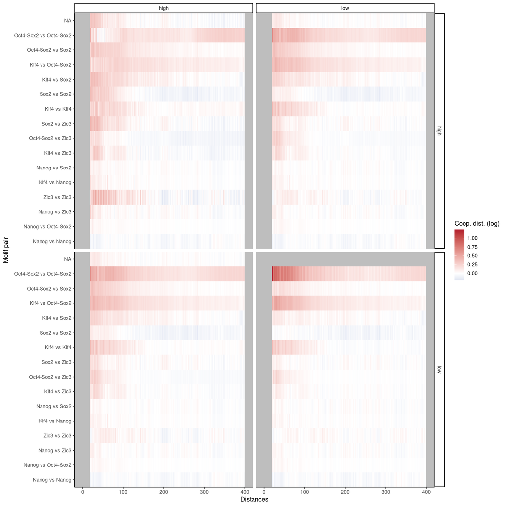

```r
pc_ratio<-.2

#Group by distance
marg_distance_summary.df<-margs.df %>%
  dplyr::filter(model_name == 'atac_wt') %>%
  dplyr::group_by(motif_pair_distance, motif_pair_ordered, model_name, affinityA, affinityB) %>%
  dplyr::mutate(add_coop_w_pc = ((hAB_sum - null_sum) + null_sum*pc_ratio)/((hA_sum + hB_sum - 2*null_sum)+ null_sum*pc_ratio)) %>%
  dplyr::summarize(median_add_coop = median(add_coop, na.rm = T),
                   median_mult_coop = median(mult_coop, na.rm = T),
                   median_add_coop_w_pc = median(add_coop_w_pc, na.rm = T))


marg_distance_summary.df<-marg_distance_summary.df%>%
  dplyr::mutate(motif_pair_ordered = factor(motif_pair_ordered, motif_pair_ordered_order))
#
#
#                   add_coop = (hAB_sum - null_sum)/(hA_sum + hB_sum - 2*null_sum),
#                   mult_coop = log(hAB_sum/null_sum)/log((hA_sum*hB_sum)/(null_sum*null_sum)),

coop_heatmap.plot<-ggplot(marg_distance_summary.df, aes(motif_pair_distance, motif_pair_ordered, fill = log(median_add_coop_w_pc)))+
  ggrastr::geom_tile_rast()+
  scale_x_continuous(name = 'Distances', limits = c(0, 400)) +
  scale_y_discrete(name = 'Motif pair', expand = c(0,0)) +
  scale_fill_gradient2(high = '#b2182b', mid = 'white', low = '#2166ac', midpoint = 0, name = 'Coop. dist. (log)')+
  facet_grid(affinityA ~ affinityB)+
  theme_classic()+  theme(panel.background = element_rect(fill = 'gray'))
coop_heatmap.plot
```

```r
ggsave(paste0(figure_filepath, '/insilico_margs_coop_add_heatmap.png'), coop_heatmap.plot, height = 4, width = 10)
ggsave(paste0(figure_filepath, '/insilico_margs_coop_add_heatmap.pdf'), coop_heatmap.plot, height = 4, width = 10)
```

# Testing the half-nucleosome theory: Moyle-Heyrman…Widom (2011)

“Taken together, these results mean that binding of LexA protein near the end of the nucleosomal DNA cooperatively influences the behavior of DNA stretches elsewhere in the nucleosome.”

“In summary, our new assays confirm our previous theoretical analysis, revealing significant positive cooperativity between diverse sites on the same side of the nucleosome, but in addition show that this positive cooperativity does not extend to diverse sites on the other side of the nucleosome.”

Do we see this also to be the case?

First, format the data and collect dyad location information.

```r
#Import dyad functions and information
source('/n/projects/mw2098/shared_code/rscripts/dyad_distance_functions.R')
dyads.gr<-rtracklayer::import('/n/projects/mw2098/analysis/chemical_mapping/mm10/H3Q85C/bed/mm10_GSM2183909_nucleosome_centers.bed.gz')

#Import motif pairs with coordinate information
perturbs_processed.gr<-perturbs_processed.df %>%
  makeGRangesFromDataFrame(seqnames.field = 'seqnames.x', start.field = 'start.x', end.field = 'end.x', strand.field = 'strand.x', keep.extra.columns = T, starts.in.df.are.0based = F)

#Find where dyads are respectively to motif.x
perturbs_processed.gr<-lapply(perturbs_processed.gr$motif.x %>% unique, function(x){
  compute_instance_to_dyad_distance(instances.gr = perturbs_processed.gr %>% plyranges::filter(motif.x == x),
                                    dyads.gr = dyads.gr)
}) %>% as('GRangesList') %>% unlist()
```

Next, organize and classify data.

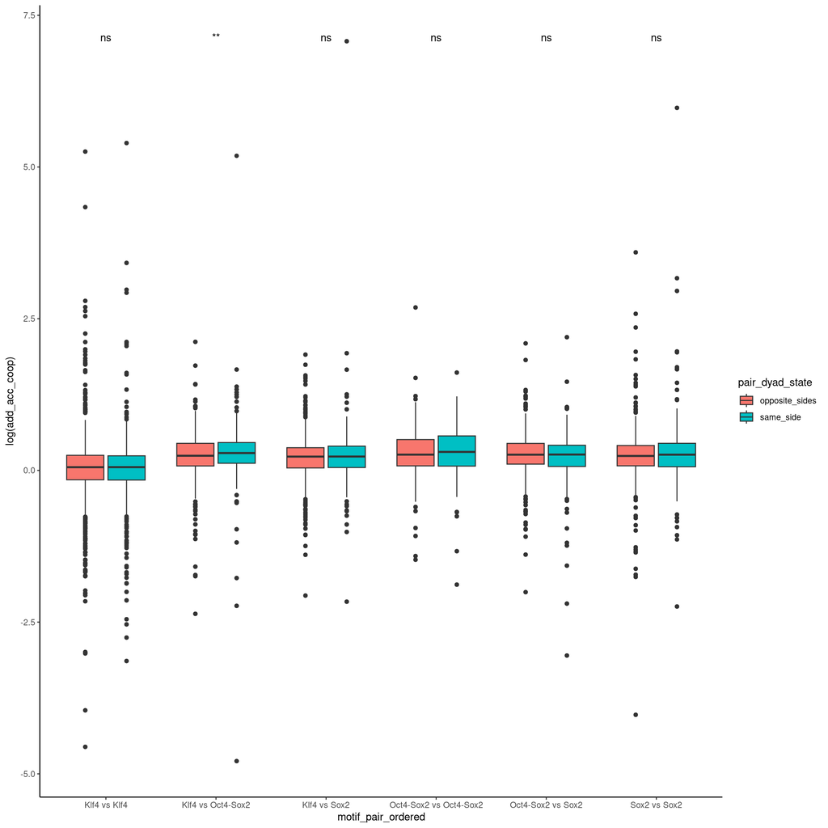

```r
perturbs_processed_w_dyads.df<-perturbs_processed.gr %>%
  plyranges::mutate(dyad_dist_from_x = start - dyad_location,
                    dyad_dist_from_y = (start.y) - dyad_location,
                    pair_dyad_state = ifelse(dyad_dist_from_x*dyad_dist_from_y>0, 'same_side', 'opposite_sides')) %>%
  plyranges::filter(abs(dyad_dist_from_x)<75, abs(dyad_dist_from_y)<75, motif.x %in% c('Oct4-Sox2','Sox2','Klf4'),
                    motif.y %in% c('Oct4-Sox2','Sox2','Klf4')) %>%
  as.data.frame %>%
  dplyr::arrange(motif_pair_ordered, dyad_dist_from_x, dyad_dist_from_y, add_acc_coop)

coop.boxplot<-ggplot(perturbs_processed_w_dyads.df %>% dplyr::filter(motif_pair_distance <70, motif_pair_distance >50),
                     aes(x = motif_pair_ordered, y = log(add_acc_coop), fill = pair_dyad_state))+
  geom_boxplot()+
  ggpubr::stat_compare_means(method = 'wilcox', label = 'p.signif')+
  theme_classic()
coop.boxplot
```

Visualize

```r
perturbs_processed_w_dyads_summary.df<-perturbs_processed_w_dyads.df %>%
  dplyr::filter(motif_pair_blind == 'Sox2 vs Sox2', start.y>start) %>%
  dplyr::mutate(motif_pair_distance_group = plyr::round_any(motif_pair_distance, accuracy = 10, f = ceiling),
                dyad_vs_x_group = plyr::round_any(dyad_dist_from_x, accuracy = 10, f = ceiling),
                dyad_vs_y_group = plyr::round_any(dyad_dist_from_y, accuracy = 10, f = ceiling)) %>%
  dplyr::group_by(motif_pair_distance_group, dyad_vs_x_group, dyad_vs_y_group, pair_dyad_state) %>%
  dplyr::summarize(count = dplyr::n(), med_acc_coop = median(add_acc_coop)) %>%
  dplyr::ungroup() %>%
  dplyr::mutate(row = 1:nrow(.))

pair_vs_dyad.plot<-ggplot(perturbs_processed_w_dyads_summary.df) +
   geom_segment(aes(x = dyad_vs_x_group, y = row, xend = dyad_vs_y_group, yend = row, color = pair_dyad_state))+
  # geom_rect(aes(xmin = dyad_dist_from_x, xmax = dyad_dist_from_y, ymin = row, ymax = row, color = count, fill = count), )+
  scale_x_continuous(name = 'distance from dyad (bp)')+
  scale_y_continuous(name = 'motif pairs (ordered by motif pair distance -> dyad position)')+
  scale_color_manual(name = 'Nucleosome state', values = c('#f1a340', '#998ec3'))+
  ggtitle('Motif pair positions relative dyads')+
  theme_classic() + theme(legend.position = 'bottom')

coop.plot<-ggplot(perturbs_processed_w_dyads_summary.df) +
  geom_tile(aes(x = 1, y = row, fill = log(med_acc_coop)))+
  scale_fill_gradient2(high = '#b2182b', mid = 'white', low = '#2166ac', midpoint = 0, name = 'Add. coop (log)')+
  scale_x_continuous(name = '')+
  scale_y_continuous(name = 'motif pairs (ordered by motif pair distance -> dyad position)')+
  ggtitle('Med. cooperativity')+
  theme_classic() + theme(legend.position = 'bottom')

coop_line.plot<-ggplot(perturbs_processed_w_dyads_summary.df) +
  geom_hline(yintercept = 0, linetype = 'dotted')+
   geom_line(aes(y = log(med_acc_coop), x = row))+
  geom_point(aes(y = log(med_acc_coop), x = row, color = pair_dyad_state), size = .5)+
  scale_x_continuous(name = 'Add. coop (log)')+
  scale_x_continuous(name = 'motif pairs (ordered by motif pair distance -> dyad position)')+
  scale_color_manual(name = 'Nucleosome state', values = c('#f1a340', '#998ec3'))+
  coord_flip()+
  ggtitle('Med. cooperativity')+
  theme_classic() + theme(legend.position = 'bottom')



plot<-pair_vs_dyad.plot + coop_line.plot + coop.plot + plot_layout(widths = c(2, 1, 1))
ggsave(paste0(figure_filepath, '/half_nucleosome_hypothesis_Sox2_vs_Sox2.png'), plot, height = 6, width = 8)
ggsave(paste0(figure_filepath, '/half_nucleosome_hypothesis_Sox2_vs_Sox2.pdf'), plot, height = 6, width = 8)
```

We really dont see evidence for this.